# Muscle ATAC QC Report

First we load in the necessary data files. For muscle, we download and load from the motrpac-data-hub: Muscle ATAC Raw data: gs://motrpac-data-hub/human-precovid/results/epigenomics/t06-muscle/epigen-atac-seq/motrpac_human-precovid_t06-muscle_epigen-atac-seq_counts.txt.gz

Muscle ATAC QC data: gs://motrpac-data-hub/human-precovid/results/epigenomics/qa-qc/motrpac_human-precovid_epigen-atac-seq_qa-qc-metrics.csv

Sample Data (for pid, sex, time point, age, visit code): gs://motrpac-data-hub/human-eqc/adult/motrpac_adult_ds_extended_qc_redacted_v5.0.csv

Human ATAC Meta (for random group code): This file has been uploaded to the pre-covid github repository at the location: (Github repositories local location)/precovid-analyses/data/human-precovid-sed-adu_epigen-atac_subject-metadata.tsv’)

```r
# First we identify the local locations to download the ATAC raw data matrices/ATAC QC data (atac_dl_directory) and to download the general sample metadata for the pre-covid study (samplemeta_dl_directory)

atac_dl_directory <- config$atac_dl_directory
samplemeta_dl_directory <- config$samplemeta_dl_directory

# Currently the google cloud reading function dl_read_gcp contains one step that involves extending file paths. This formatting depends on the operating system used for the analysis. For example, by default, the code runs fine on a linux or mac operating system by using a "/" to extend the file path. For windows machines, however, the appropriate command is appending is "\\". For now I have hard-coded the full functionality of dl_read_gcp in this rmd file and included in my config file a "IsWindows" variable to determine the right approach below.
gsutil_path = config$gsutil_user
verbose = TRUE
check_first = TRUE
sep = "\t"
header = T
IsWindows = config$IsWindows

####
# First we download the muscle atac raw data
####

tmpdir = atac_dl_directory
path = "gs://motrpac-data-hub/human-precovid/results/epigenomics/t06-muscle/epigen-atac-seq/motrpac_human-precovid_t06-muscle_epigen-atac-seq_counts.txt.gz"

# Creates the download folder location if necessary
if (!dir.exists(tmpdir)) {
  dir.create(tmpdir)
  if (verbose)
    message(paste0("- New folder ", tmpdir, " created successfully"))
}

tmpdir <- normalizePath(tmpdir)

if (!grepl("gs:\\/\\/", path)) {
  stop("The path to the bucket is wrong. Valid example: gs://bucket-name/file-name.csv")
} else {
  if(IsWindows){
    new_path <- file.path(tmpdir, basename(path),fsep = "\\")
  } else {
    new_path <- file.path(tmpdir, basename(path))
  }
}

# Downloads the file if it doesn't currently exist from the google cloud project. Make sure you have downloaded gsutil to your machine and have authorized your computer to access your google cloud projects (gcloud auth login command in terminal/command prompt)
if (check_first) {
  if (!file.exists(new_path)) {
    cmd <- sprintf("%s cp %s %s", gsutil_path, path,
                   tmpdir)
    if (verbose)
      message(paste0("- Running command ", cmd))
    system(cmd)
    message("- Downloaded file: ", new_path)
  } else {
    if (verbose)
      message(paste0("- The file <", new_path, "> already exists"))
  }
} else {
  if (verbose)
    message(paste("- Downloading file (from GCP) <",
                  basename(path), ">"))
  cmd <- sprintf("%s cp %s %s", gsutil_path, path, tmpdir)
  system(cmd, ignore.stdout = ignore_std_out, ignore.stderr = ignore_std_err)
  message("- Downloaded file: ", new_path)
}
```

```
## - The file <C:\Users\gsmit\Documents\PreCovid_Data\ATACseq\motrpac_human-precovid_t06-muscle_epigen-atac-seq_counts.txt.gz> already exists
```

```r
# Now that the downloaded file exists locally, we load the file for further analysis. Note that we're using data frames, not data tables here.
if (file.exists(new_path)) {
  muscleatac <- read.delim(new_path, sep = sep, header = header)
} else {
  stop("- Problems loading the file")
}

####
# Second we download the atac qc data
####

tmpdir = atac_dl_directory
path = "gs://motrpac-data-hub/human-precovid/results/epigenomics/qa-qc/motrpac_human-precovid_epigen-atac-seq_qa-qc-metrics.csv"

# Creates the download folder location if necessary
if (!dir.exists(tmpdir)) {
  dir.create(tmpdir)
  if (verbose)
    message(paste0("- New folder ", tmpdir, " created successfully"))
}

tmpdir <- normalizePath(tmpdir)

if (!grepl("gs:\\/\\/", path)) {
  stop("The path to the bucket is wrong. Valid example: gs://bucket-name/file-name.csv")
} else {
  new_path <- file.path(tmpdir, basename(path),fsep = "\\")
}

# Downloads the file if it doesn't currently exist from the google cloud project. Make sure you have downloaded gsutil to your machine and have authorized your computer to access your google cloud projects (gcloud auth login command in terminal/command prompt)
if (check_first) {
  if (!file.exists(new_path)) {
    cmd <- sprintf("%s cp %s %s", gsutil_path, path,
                   tmpdir)
    if (verbose)
      message(paste0("- Running command ", cmd))
    system(cmd)
    message("- Downloaded file: ", new_path)
  } else {
    if (verbose)
      message(paste0("- The file <", new_path, "> already exists"))
  }
} else {
  if (verbose)
    message(paste("- Downloading file (from GCP) <",
                  basename(path), ">"))
  cmd <- sprintf("%s cp %s %s", gsutil_path, path, tmpdir)
  system(cmd, ignore.stdout = ignore_std_out, ignore.stderr = ignore_std_err)
  message("- Downloaded file: ", new_path)
}
```

```
## - The file <C:\Users\gsmit\Documents\PreCovid_Data\ATACseq\motrpac_human-precovid_epigen-atac-seq_qa-qc-metrics.csv> already exists
```

```r
# Now that the downloaded file exists locally, we load the file for further analysis. Note that we're using data frames, not data tables here.
if (file.exists(new_path)) {
  muscleatacqc <- read.csv(new_path,row.names = 1,header = header)
} else {
  stop("- Problems loading the file")
}

####
# Third we download a precovid extended qc file that allows conversion of viallabels to PIDs as well as providing select subject metadata like sex, timepoint, age and visitcode. The PID conversion is essential to access further subject-related metadata
####

tmpdir = samplemeta_dl_directory
path = "gs://motrpac-data-hub/human-eqc/adult/motrpac_adult_ds_extended_qc_redacted_v5.0.csv"

# Creates the download folder location if necessary
if (!dir.exists(tmpdir)) {
  dir.create(tmpdir)
  if (verbose)
    message(paste0("- New folder ", tmpdir, " created successfully"))
}

tmpdir <- normalizePath(tmpdir)

if (!grepl("gs:\\/\\/", path)) {
  stop("The path to the bucket is wrong. Valid example: gs://bucket-name/file-name.csv")
} else {
  new_path <- file.path(tmpdir, basename(path),fsep = "\\")
}

# Downloads the file if it doesn't currently exist from the google cloud project. Make sure you have downloaded gsutil to your machine and have authorized your computer to access your google cloud projects (gcloud auth login command in terminal/command prompt)
if (check_first) {
  if (!file.exists(new_path)) {
    cmd <- sprintf("%s cp %s %s", gsutil_path, path,
                   tmpdir)
    if (verbose)
      message(paste0("- Running command ", cmd))
    system(cmd)
    message("- Downloaded file: ", new_path)
  } else {
    if (verbose)
      message(paste0("- The file <", new_path, "> already exists"))
  }
} else {
  if (verbose)
    message(paste("- Downloading file (from GCP) <",
                  basename(path), ">"))
  cmd <- sprintf("%s cp %s %s", gsutil_path, path, tmpdir)
  system(cmd, ignore.stdout = ignore_std_out, ignore.stderr = ignore_std_err)
  message("- Downloaded file: ", new_path)
}
```

```
## - The file <C:\Users\gsmit\Documents\PreCovid_Data\Metadata\motrpac_adult_ds_extended_qc_redacted_v5.0.csv> already exists
```

```r
# Now that the downloaded file exists locally, we load the file for further analysis. Note that we're using data frames, not data tables here.
if (file.exists(new_path)) {
  sampledata <- read.csv(new_path,header = header)
} else {
  stop("- Problems loading the file")
}

####
# Fourth we download the atac subject metadata file. This is not currently on the motrpac-data-hub, but it has been provided in the precovid-analyes github repository. This file connects PIDs to further subject-level metadata randomGroupCode and codedSiteID
####

humanatacmeta <- read.delim(file = paste0(config$precovid_repo_path, 'data/human-precovid-sed-adu_epigen-atac_subject-metadata.tsv'),header = T)

# Polishing of dataframes to remove excess characters from column names and generate proper unique rownames for ATAC features
colnames(muscleatac) <- gsub("X","",colnames(muscleatac))
rownames(muscleatac) <- paste(muscleatac$chrom,":",muscleatac$start,"-",muscleatac$end,sep = "")
muscleatacpeakmeta <- muscleatac[,c("chrom","start","end")]
muscleatac <- muscleatac[,c(4:dim(muscleatac)[2])]

# We remove X and Y chromosomes from downstream ATAC analysis
muscleatacpeakmeta <- muscleatacpeakmeta[!(muscleatacpeakmeta$chrom %in% c("chrX","chrY")),]
muscleatac <- muscleatac[rownames(muscleatacpeakmeta),]
```

We coalesce the metadata into one data frame using the sampledata and humanatacmeta objects as sources

```r
muscleatacmeta <- data.frame(row.names = colnames(muscleatac),
                            "viallabel" = colnames(muscleatac))
muscleatacmeta$pid <- 0
muscleatacmeta$sex <- 1
muscleatacmeta$group <- ""
muscleatacmeta$timepoint <- ""
muscleatacmeta$age <- 0
muscleatacmeta$pre_or_post_visit <- ""
muscleatacmeta$age_groups <- "0"
muscleatacmeta$CodedSiteID <- 0

for(i in 1:dim(muscleatacmeta)[1]){
  ourviallabel <- rownames(muscleatacmeta)[i]
  ourpid <- sampledata[sampledata$vialLabel %in% ourviallabel,"pid"][1]
  muscleatacmeta[i,"pid"] <- ourpid
  muscleatacmeta[i,"sex"] <- sampledata[sampledata$vialLabel %in% ourviallabel,"sex_psca"][1]
  muscleatacmeta[i,"timepoint"] <- sampledata[sampledata$vialLabel %in% ourviallabel,"timepointDescription"][1]
  muscleatacmeta[i,"group"] <- humanatacmeta[humanatacmeta$PID %in% ourpid,"randomGroupCode"][1]
  muscleatacmeta[i,"age"] <- sampledata[sampledata$vialLabel %in% ourviallabel,"calculatedAge"][1]
  muscleatacmeta[i,"pre_or_post_visit"] <- sampledata[sampledata$vialLabel %in% ourviallabel,"visitcode"][1]
  muscleatacmeta$CodedSiteID[i] <- humanatacmeta[humanatacmeta$PID %in% muscleatacmeta$pid[i],"codedSiteID"][1]
  if(!is.na(muscleatacmeta[i,"age"]) & muscleatacmeta[i,"age"] >= 18 & muscleatacmeta[i,"age"] <= 35){
    muscleatacmeta[i,"age_groups"] <- "18-35"
  }
  if(!is.na(muscleatacmeta[i,"age"]) & muscleatacmeta[i,"age"] >= 36 & muscleatacmeta[i,"age"] <= 50){
    muscleatacmeta[i,"age_groups"] <- "36-50"
  }
  if(!is.na(muscleatacmeta[i,"age"]) & muscleatacmeta[i,"age"] >= 51 & muscleatacmeta[i,"age"] <= 65){
    muscleatacmeta[i,"age_groups"] <- "51-65"
  }
  if(!is.na(muscleatacmeta[i,"age"]) & muscleatacmeta[i,"age"] >= 66 & muscleatacmeta[i,"age"] <= 80){
    muscleatacmeta[i,"age_groups"] <- "66-80"
  }
}

muscleatacmeta$age_groups <- factor(muscleatacmeta$age_groups,levels = c("18-35","36-50","51-65","66-80"))

muscleatacqc <- muscleatacqc[rownames(muscleatacmeta),]
muscleatacmeta$peak_enrich.frac_reads_in_peaks.macs2.frip <- muscleatacqc[rownames(muscleatacmeta),"peak_enrich.frac_reads_in_peaks.macs2.frip"]
muscleatacmeta$align_enrich.tss_enrich.tss_enrich <- muscleatacqc[rownames(muscleatacmeta),"align_enrich.tss_enrich.tss_enrich"]

muscleatacmeta$time <- muscleatacmeta$timepoint
muscleatacmeta[muscleatacmeta$timepoint %in% "24 hr Rest 3","time"] <- "24hrPost"
muscleatacmeta[muscleatacmeta$timepoint %in% "24 hr post","time"] <- "24hrPost"
muscleatacmeta[muscleatacmeta$timepoint %in% "3.5 hr Rest 3","time"] <- "3.5hrPost"
muscleatacmeta[muscleatacmeta$timepoint %in% "3.5 hr post","time"] <- "3.5hrPost"
muscleatacmeta[muscleatacmeta$timepoint %in% "15 min Rest 3","time"] <- "15minPost"
muscleatacmeta[muscleatacmeta$timepoint %in% "15 min post","time"] <- "15minPost"
muscleatacmeta[muscleatacmeta$timepoint %in% "Rest 1","time"] <- "Pre.Exercise"
muscleatacmeta[muscleatacmeta$timepoint %in% "Pre ex","time"] <- "Pre.Exercise"

muscleatacmeta$sex <- c("Female","Male")[muscleatacmeta$sex]

muscleatacmeta$group_timepoint <- interaction(muscleatacmeta$group,muscleatacmeta$time)
```

We isolate the sedentary subjects from the baseline acute bout. Among the muscle samples, there are five control pre-exercise samples from the second acute bout that we are excluding from this analysis. We isolate the QC data for the sedentary subjects and produce a muscle qc output file.. We then examine the distribution of subjects across sex, group and time point.

```r
muscleatacmeta <- muscleatacmeta[muscleatacmeta$group %in% c("ADUControl","ADUEndur","ADUResist") & muscleatacmeta$pre_or_post_visit %in% "ADU_BAS",]
muscleatac <- muscleatac[,rownames(muscleatacmeta)]

muscleatacmeta_expand <- cbind(muscleatacmeta,muscleatacqc[rownames(muscleatacmeta),])
muscleatacmeta_expand <- muscleatacmeta_expand[,unique(colnames(muscleatacmeta_expand))]

write.table(muscleatacmeta_expand,file = "human-precovid-sed-adu_t06-human-muscle_epigen-atac-seq_metadata_samples_v1.txt",sep = "\t",quote = F)

muscleatacmeta$Sample_batch <- muscleatacmeta_expand[rownames(muscleatacmeta),"Sample_batch"]

table(muscleatacmeta[!duplicated(muscleatacmeta$pid),"group"],muscleatacmeta[!duplicated(muscleatacmeta$pid),"sex"])
```

```
##
##              Female Male
##   ADUControl      8    6
##   ADUEndur        4    9
##   ADUResist       5    5
```

```r
table(muscleatacmeta[!duplicated(muscleatacmeta$pid),"group"],muscleatacmeta[!duplicated(muscleatacmeta$pid),"age_groups"])
```

```
##
##              18-35 36-50 51-65 66-80
##   ADUControl     6     1     5     2
##   ADUEndur       5     4     3     1
##   ADUResist      3     3     3     1
```

```r
table(muscleatacmeta[!duplicated(muscleatacmeta$pid) & muscleatacmeta$group %in% "ADUControl","sex"],muscleatacmeta[!duplicated(muscleatacmeta$pid) & muscleatacmeta$group %in% "ADUControl","age_groups"])
```

```
##
##          18-35 36-50 51-65 66-80
##   Female     3     1     4     0
##   Male       3     0     1     2
```

```r
table(muscleatacmeta[!duplicated(muscleatacmeta$pid) & muscleatacmeta$group %in% "ADUResist","sex"],muscleatacmeta[!duplicated(muscleatacmeta$pid) & muscleatacmeta$group %in% "ADUResist","age_groups"])
```

```
##
##          18-35 36-50 51-65 66-80
##   Female     1     2     1     1
##   Male       2     1     2     0
```

```r
table(muscleatacmeta[!duplicated(muscleatacmeta$pid) & muscleatacmeta$group %in% "ADUEndur","sex"],muscleatacmeta[!duplicated(muscleatacmeta$pid) & muscleatacmeta$group %in% "ADUEndur","age_groups"])
```

```
##
##          18-35 36-50 51-65 66-80
##   Female     1     2     1     0
##   Male       4     2     2     1
```

```r
table(muscleatacmeta[muscleatacmeta$group %in% "ADUControl","time"],muscleatacmeta[muscleatacmeta$group %in% "ADUControl","sex"])
```

```
##
##                Female Male
##   15minPost         6    4
##   24hrPost          6    4
##   3.5hrPost         5    4
##   Pre.Exercise      7    6
```

```r
table(muscleatacmeta[muscleatacmeta$group %in% "ADUResist","time"],muscleatacmeta[muscleatacmeta$group %in% "ADUResist","sex"])
```

```
##
##                Female Male
##   15minPost         5    5
##   24hrPost          4    5
##   3.5hrPost         4    5
##   Pre.Exercise      5    5
```

```r
table(muscleatacmeta[muscleatacmeta$group %in% "ADUEndur","time"],muscleatacmeta[muscleatacmeta$group %in% "ADUEndur","sex"])
```

```
##
##                Female Male
##   15minPost         3    6
##   24hrPost          2    4
##   3.5hrPost         3    6
##   Pre.Exercise      4    9
```

Groups, sexes and time points are not evenly distributed among batches or clinical sites

```r
table(muscleatacmeta_expand$Sample_batch,muscleatacmeta_expand$group)
```

```
##
##      ADUControl ADUEndur ADUResist
##   17          8        0         0
##   18          6        0         0
##   19          3        0         0
##   20          5        0         0
##   21          2        0         0
##   22          4        0         0
##   23          4        0         0
##   24          4        0         0
##   25          2        0         0
##   27          0        1         0
##   28          0        2         0
##   29          0        4         0
##   30          0        3         0
```

[output cut: 16 more lines]

```r
table(muscleatacmeta_expand$Sample_batch,muscleatacmeta_expand$sex)
```

```
##
##      Female Male
##   17      4    4
##   18      2    4
##   19      0    3
##   20      4    1
##   21      0    2
##   22      4    0
##   23      4    0
##   24      4    0
##   25      1    1
##   27      0    1
##   28      0    2
##   29      0    4
##   30      0    3
```

[output cut: 16 more lines]

```r
table(muscleatacmeta_expand$Sample_batch,muscleatacmeta_expand$time)
```

```
##
##      15minPost 24hrPost 3.5hrPost Pre.Exercise
##   17         1        2         2            3
##   18         1        2         1            2
##   19         0        1         1            1
##   20         1        2         1            1
##   21         0        0         1            1
##   22         1        1         1            1
##   23         1        1         1            1
##   24         2        1         0            1
##   25         0        0         1            1
##   27         0        0         0            1
##   28         0        1         1            0
##   29         1        1         1            1
##   30         1        1         0            1
```

[output cut: 16 more lines]

```r
table(muscleatacmeta_expand[!duplicated(muscleatacmeta_expand$pid),"CodedSiteID"],muscleatacmeta_expand[!duplicated(muscleatacmeta_expand$pid),"sex"])
```

```
##
##      Female Male
##   21      1    0
##   22      4    4
##   23      3    6
##   24      2    3
##   25      2    0
##   26      4    5
##   27      0    1
##   30      0    1
##   31      1    0
```

```r
table(muscleatacmeta_expand[!duplicated(muscleatacmeta_expand$pid),"CodedSiteID"],muscleatacmeta_expand[!duplicated(muscleatacmeta_expand$pid),"group"])
```

```
##
##      ADUControl ADUEndur ADUResist
##   21          0        0         1
##   22          3        3         2
##   23          3        4         2
##   24          1        3         1
##   25          2        0         0
##   26          4        3         2
##   27          0        0         1
##   30          1        0         0
##   31          0        0         1
```

```r
table(muscleatacmeta_expand[!duplicated(muscleatacmeta_expand$pid),"CodedSiteID"],muscleatacmeta_expand[!duplicated(muscleatacmeta_expand$pid),"age_groups"])
```

```
##
##      18-35 36-50 51-65 66-80
##   21     1     0     0     0
##   22     4     0     1     3
##   23     3     2     3     1
##   24     3     2     0     0
##   25     0     1     1     0
##   26     1     2     6     0
##   27     1     0     0     0
##   30     1     0     0     0
##   31     0     1     0     0
```

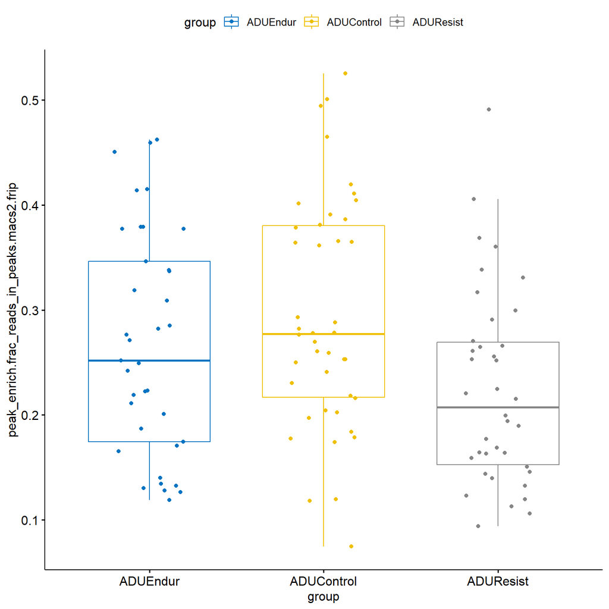

```r
ggboxplot(muscleatacmeta_expand,x = "group",y = "peak_enrich.frac_reads_in_peaks.macs2.frip",color = "group",palette = "jco",add = "jitter")
```

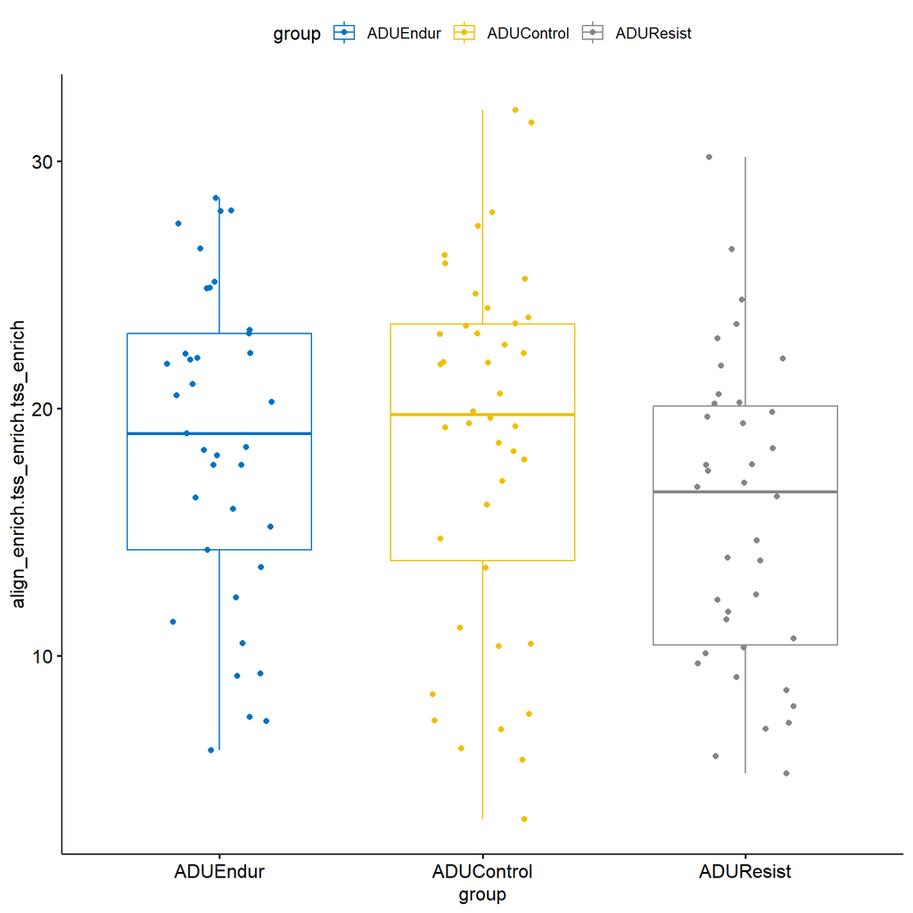

```r
ggboxplot(muscleatacmeta_expand,x = "group",y = "align_enrich.tss_enrich.tss_enrich",color = "group",palette = "jco",add = "jitter")
```

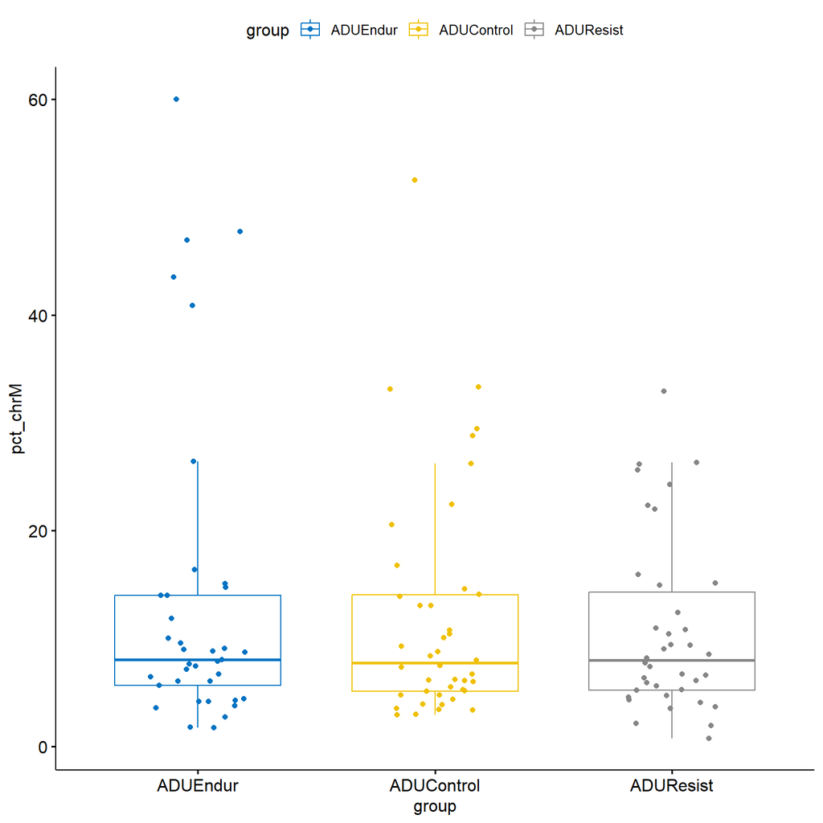

```r
ggboxplot(muscleatacmeta_expand,x = "group",y = "pct_chrM",color = "group",palette = "jco",add = "jitter")
```

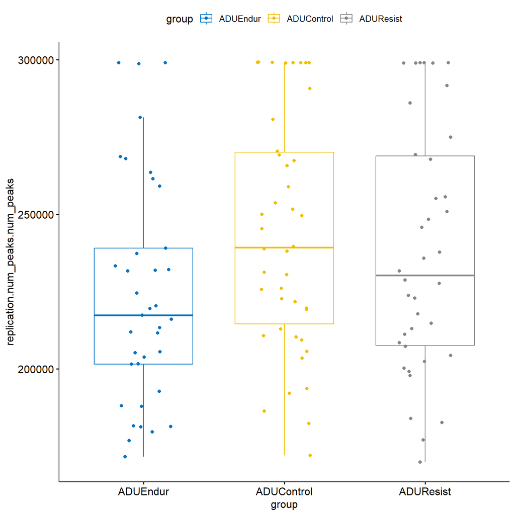

```r
ggboxplot(muscleatacmeta_expand,x = "group",y = "replication.num_peaks.num_peaks",color = "group",palette = "jco",add = "jitter")
```

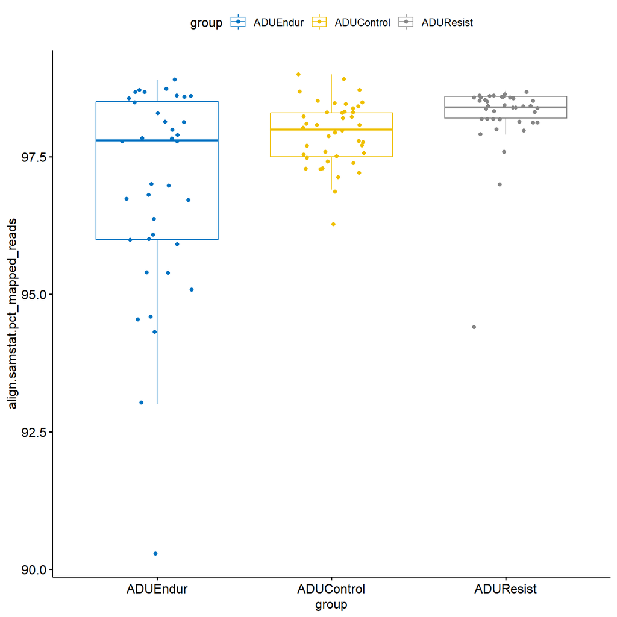

```r
ggboxplot(muscleatacmeta_expand,x = "group",y = "align.samstat.pct_mapped_reads",color = "group",palette = "jco",add = "jitter")
```

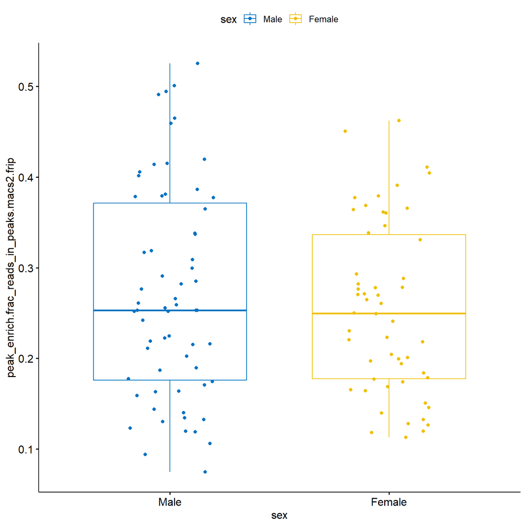

```r
ggboxplot(muscleatacmeta_expand,x = "sex",y = "peak_enrich.frac_reads_in_peaks.macs2.frip",color = "sex",palette = "jco",add = "jitter")
```

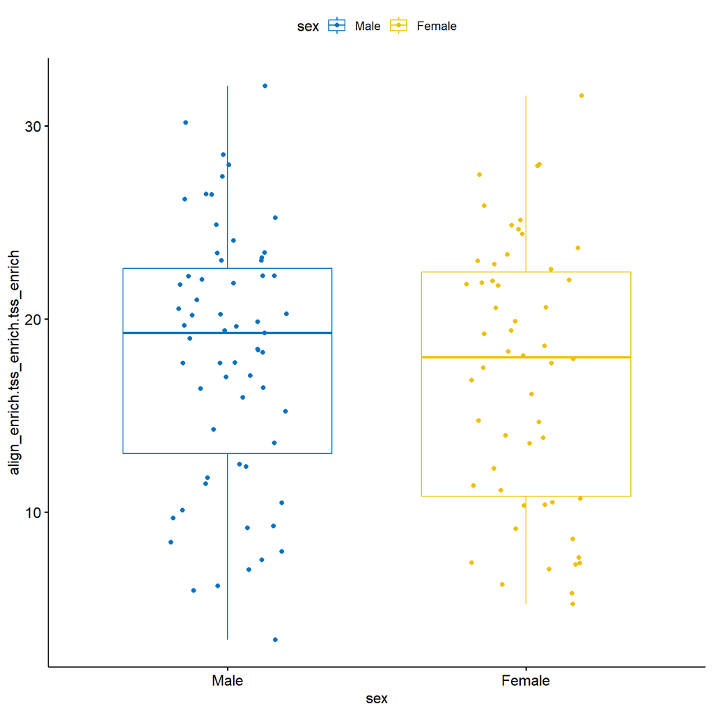

```r
ggboxplot(muscleatacmeta_expand,x = "sex",y = "align_enrich.tss_enrich.tss_enrich",color = "sex",palette = "jco",add = "jitter")
```

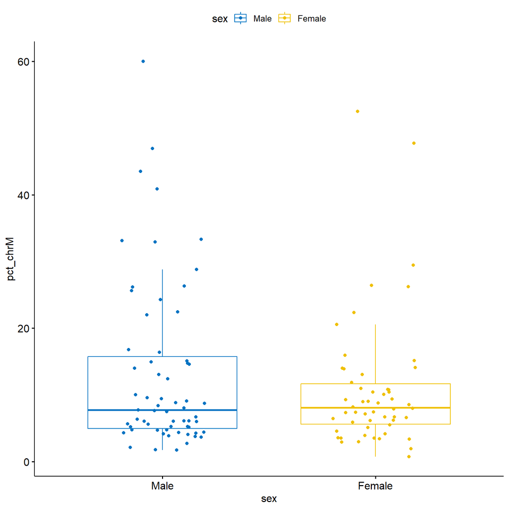

```r
ggboxplot(muscleatacmeta_expand,x = "sex",y = "pct_chrM",color = "sex",palette = "jco",add = "jitter")
```

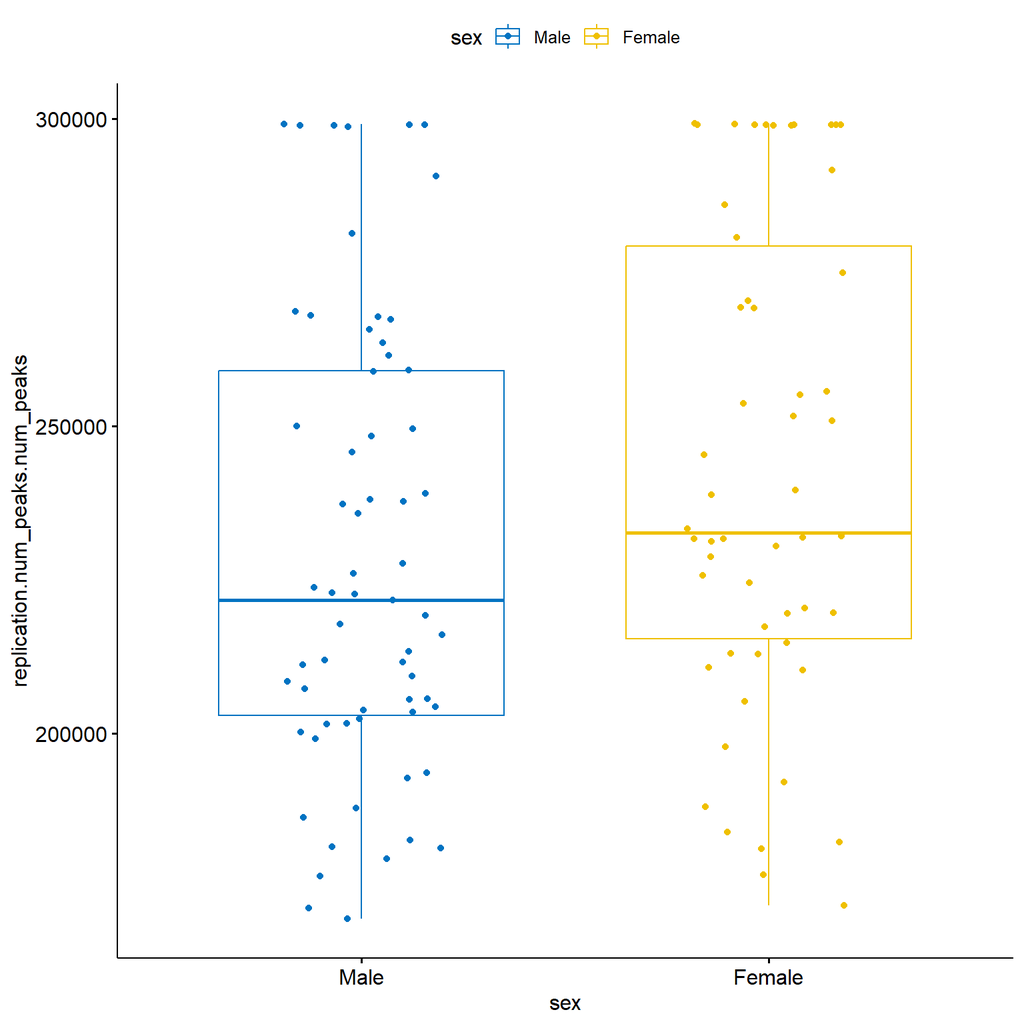

```r
ggboxplot(muscleatacmeta_expand,x = "sex",y = "replication.num_peaks.num_peaks",color = "sex",palette = "jco",add = "jitter")
```

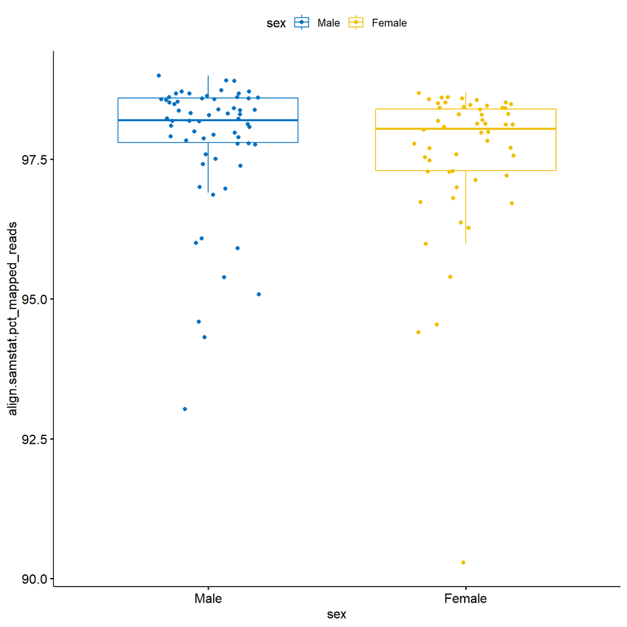

```r
ggboxplot(muscleatacmeta_expand,x = "sex",y = "align.samstat.pct_mapped_reads",color = "sex",palette = "jco",add = "jitter")
```

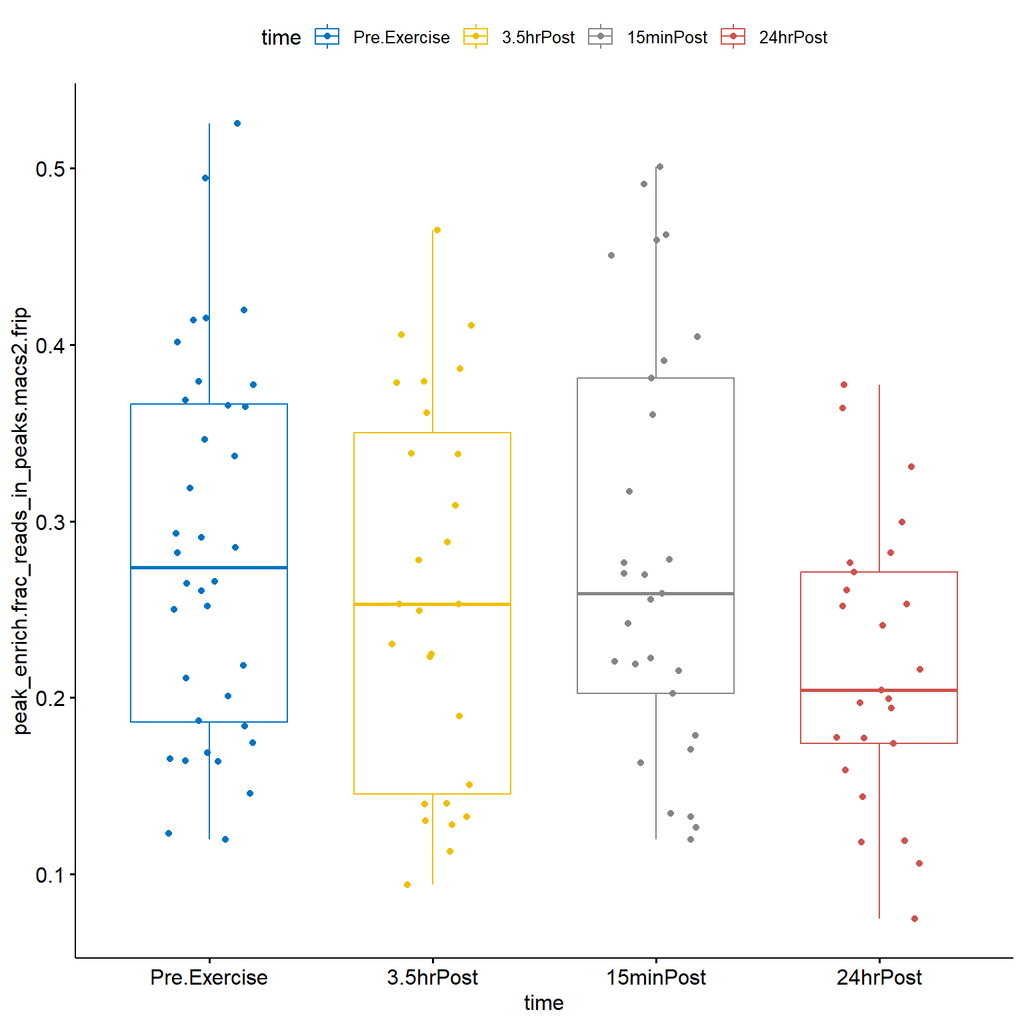

```r
ggboxplot(muscleatacmeta_expand,x = "time",y = "peak_enrich.frac_reads_in_peaks.macs2.frip",color = "time",palette = "jco",add = "jitter")
```

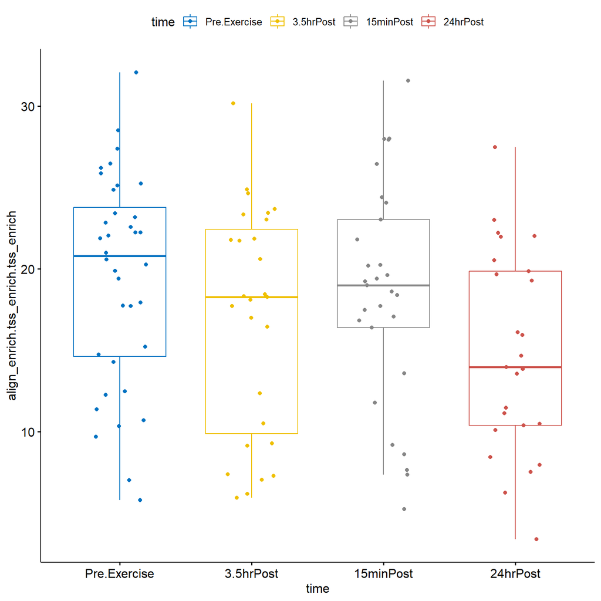

```r
ggboxplot(muscleatacmeta_expand,x = "time",y = "align_enrich.tss_enrich.tss_enrich",color = "time",palette = "jco",add = "jitter")
```

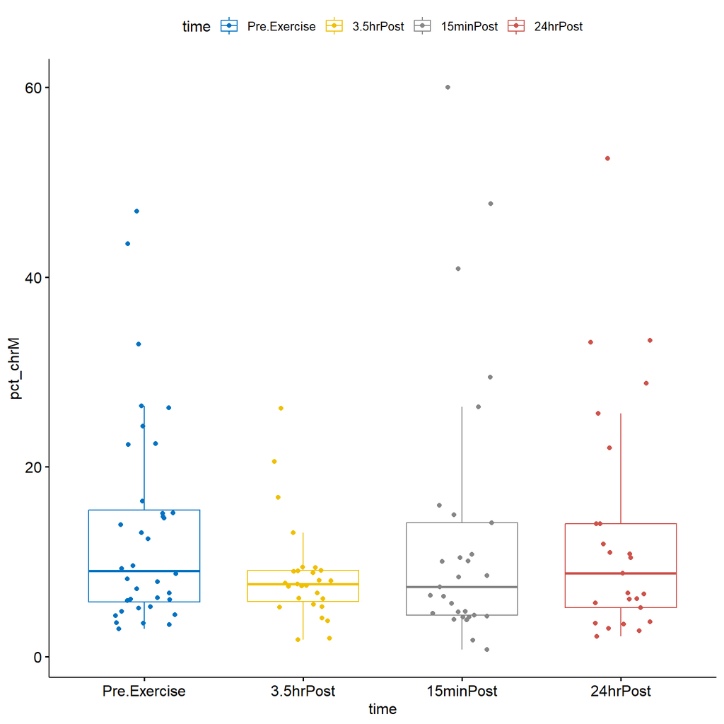

```r
ggboxplot(muscleatacmeta_expand,x = "time",y = "pct_chrM",color = "time",palette = "jco",add = "jitter")
```

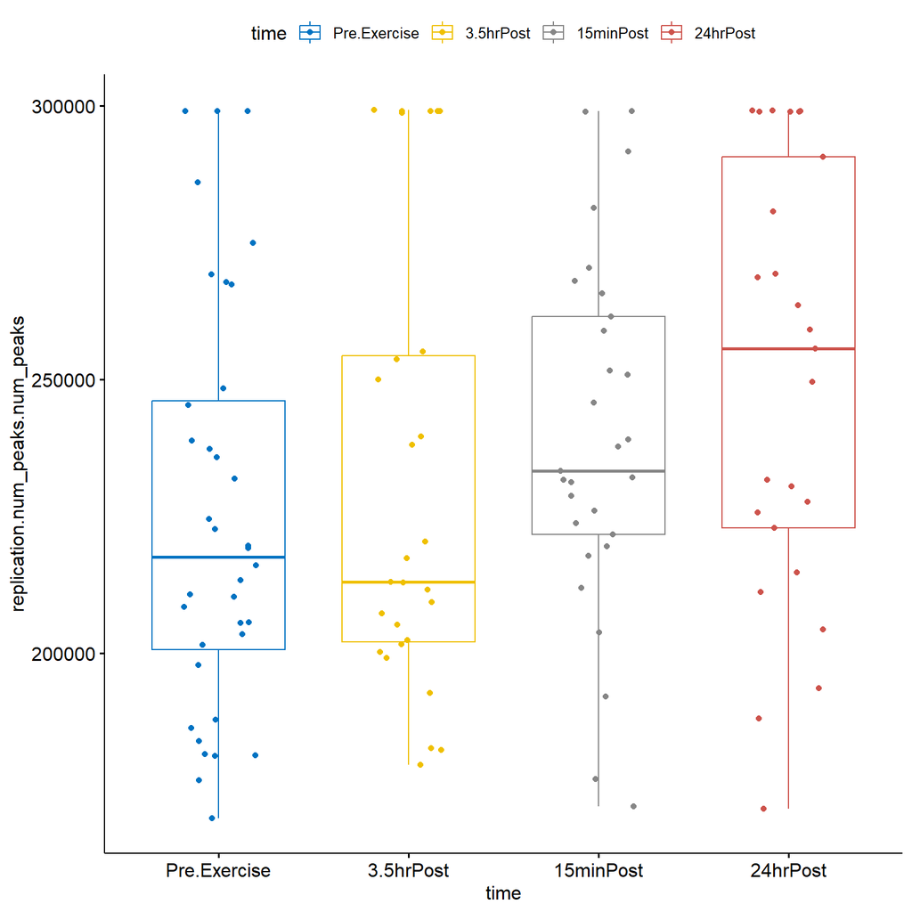

```r
ggboxplot(muscleatacmeta_expand,x = "time",y = "replication.num_peaks.num_peaks",color = "time",palette = "jco",add = "jitter")
```

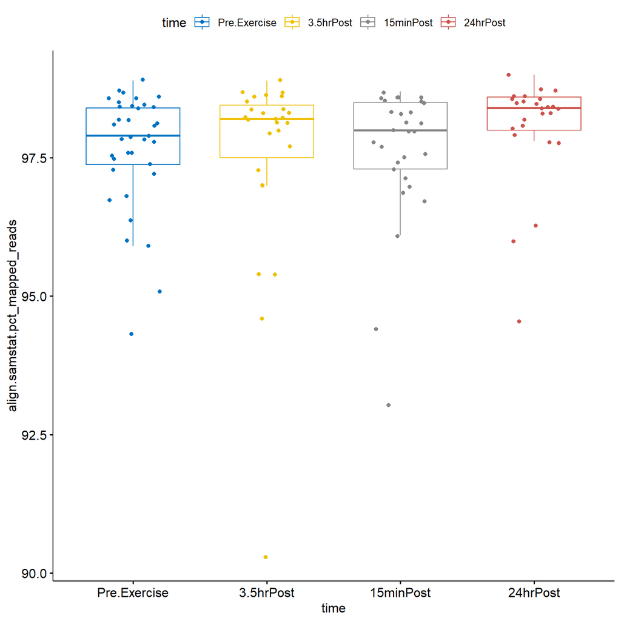

```r
ggboxplot(muscleatacmeta_expand,x = "time",y = "align.samstat.pct_mapped_reads",color = "time",palette = "jco",add = "jitter")
```

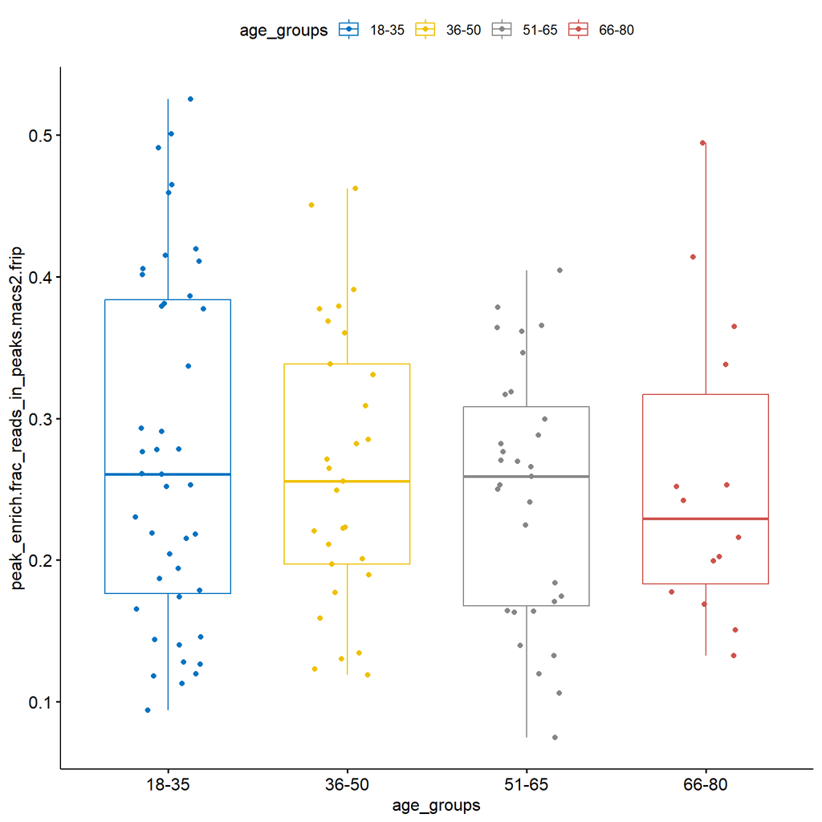

```r
ggboxplot(muscleatacmeta_expand,x = "age_groups",y = "peak_enrich.frac_reads_in_peaks.macs2.frip",color = "age_groups",palette = "jco",add = "jitter")
```

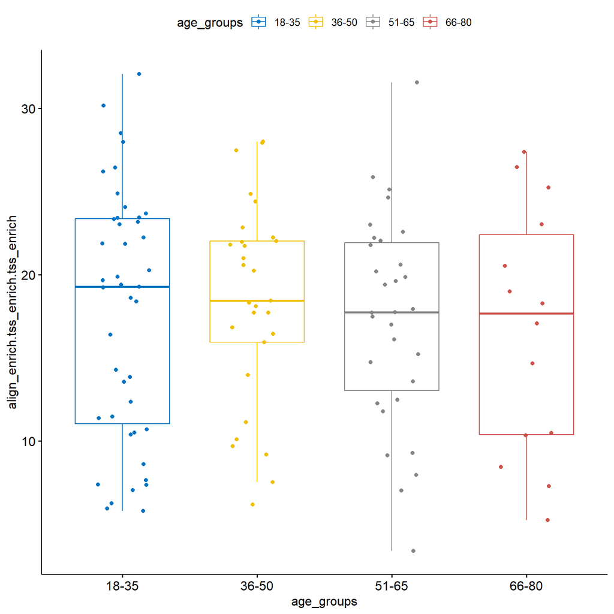

```r
ggboxplot(muscleatacmeta_expand,x = "age_groups",y = "align_enrich.tss_enrich.tss_enrich",color = "age_groups",palette = "jco",add = "jitter")
```

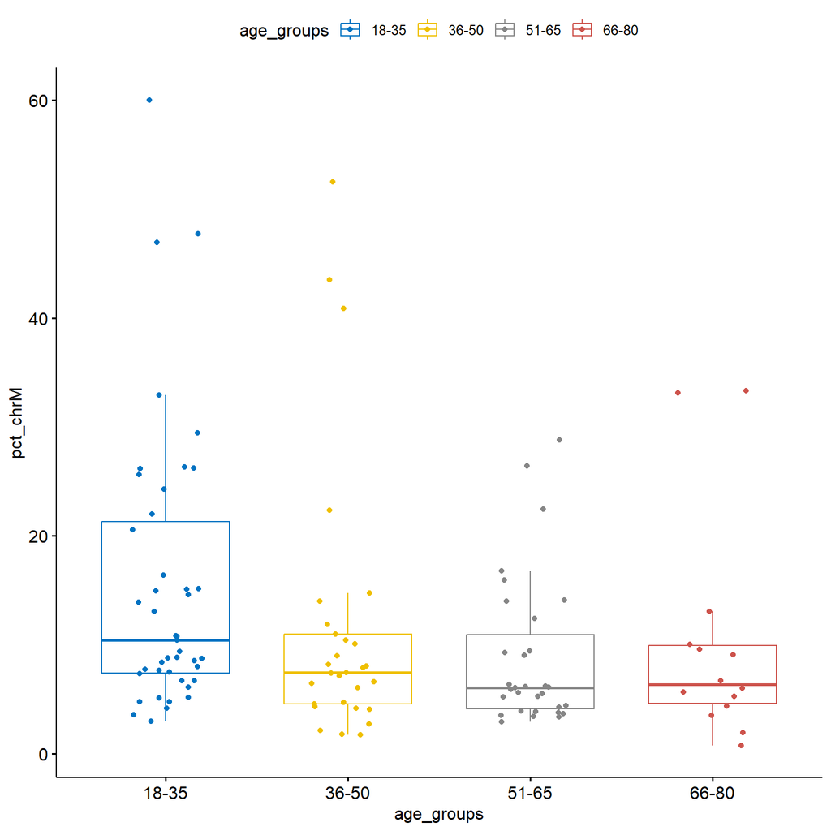

```r
ggboxplot(muscleatacmeta_expand,x = "age_groups",y = "pct_chrM",color = "age_groups",palette = "jco",add = "jitter")
```

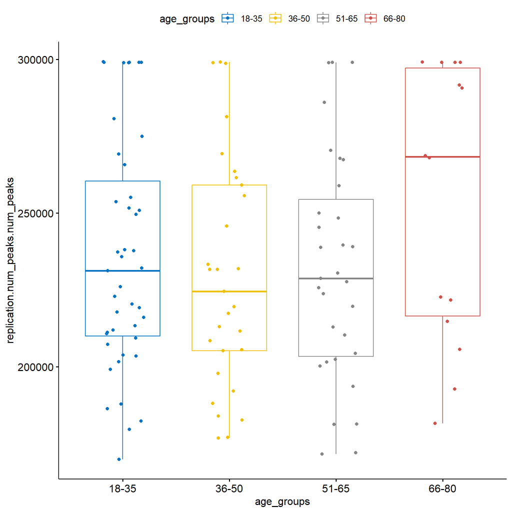

```r
ggboxplot(muscleatacmeta_expand,x = "age_groups",y = "replication.num_peaks.num_peaks",color = "age_groups",palette = "jco",add = "jitter")
```

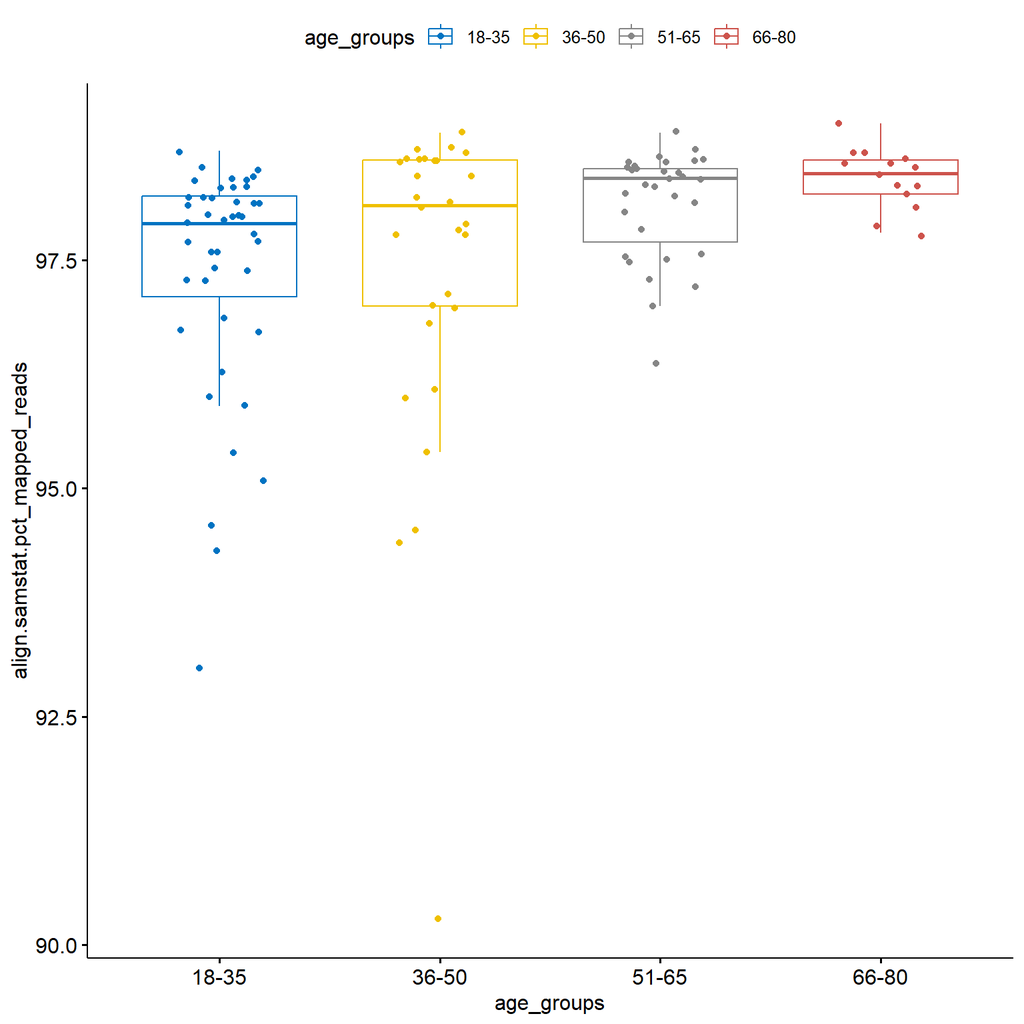

```r
ggboxplot(muscleatacmeta_expand,x = "age_groups",y = "align.samstat.pct_mapped_reads",color = "age_groups",palette = "jco",add = "jitter")
```

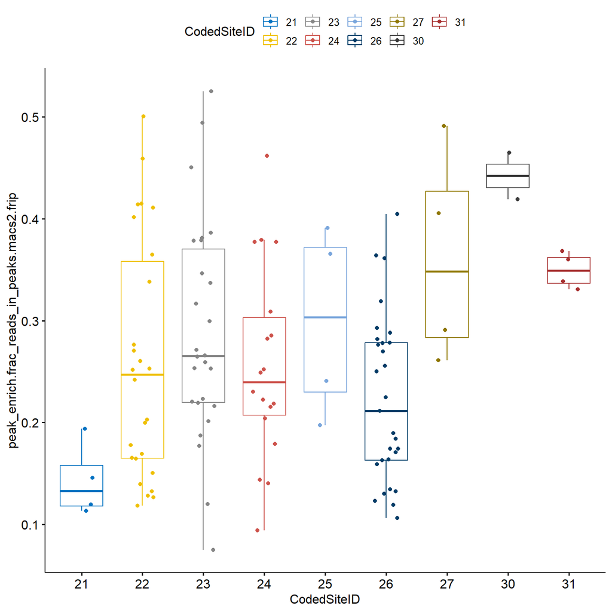

```r
ggboxplot(muscleatacmeta_expand,x = "CodedSiteID",y = "peak_enrich.frac_reads_in_peaks.macs2.frip",color = "CodedSiteID",palette = "jco",add = "jitter")
```

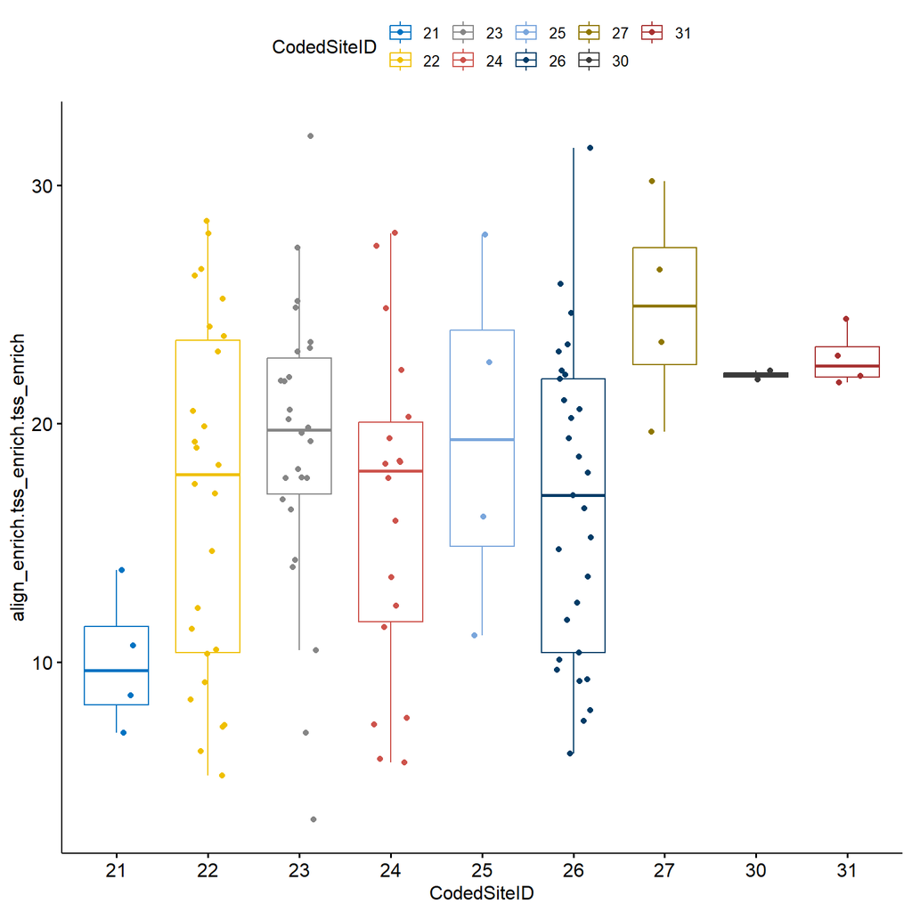

```r
ggboxplot(muscleatacmeta_expand,x = "CodedSiteID",y = "align_enrich.tss_enrich.tss_enrich",color = "CodedSiteID",palette = "jco",add = "jitter")
```

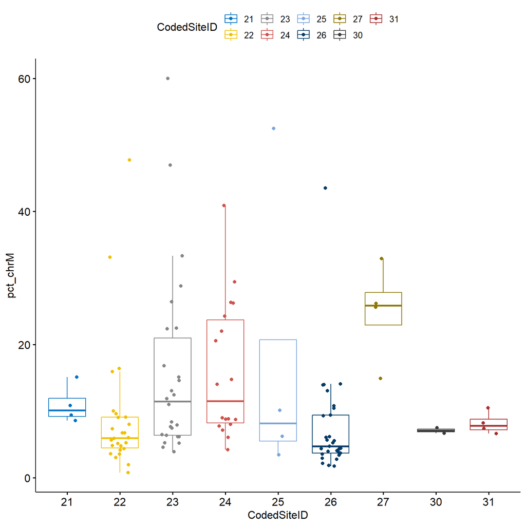

```r
ggboxplot(muscleatacmeta_expand,x = "CodedSiteID",y = "pct_chrM",color = "CodedSiteID",palette = "jco",add = "jitter")
```

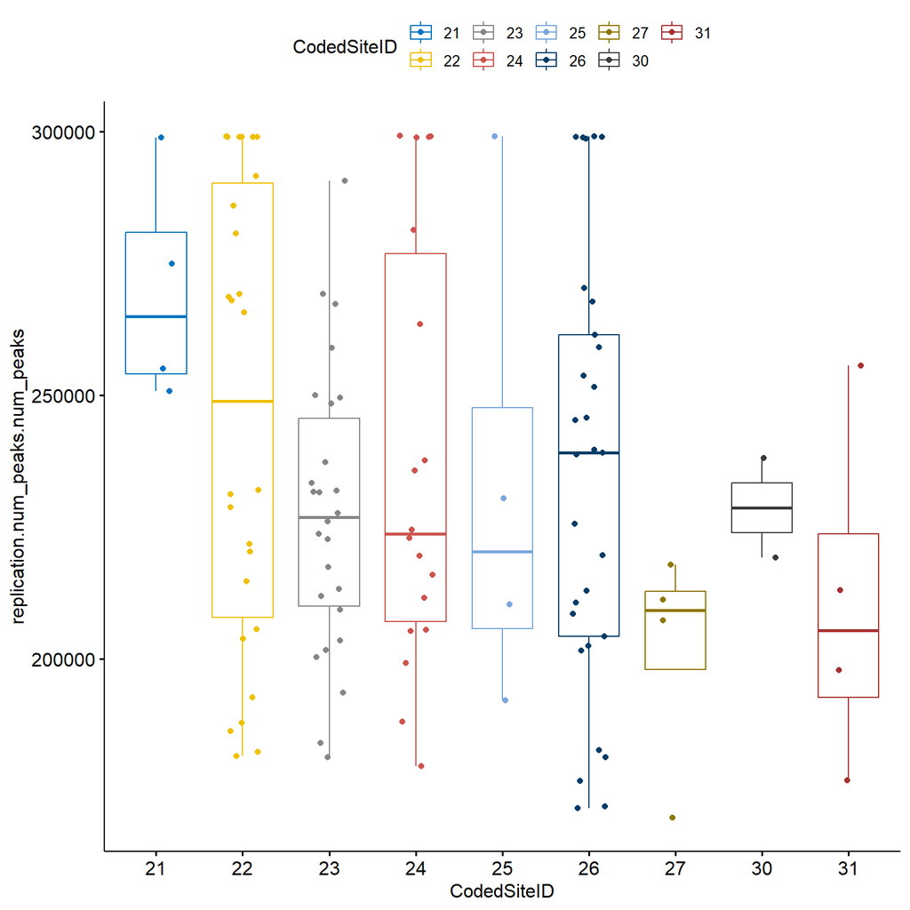

```r
ggboxplot(muscleatacmeta_expand,x = "CodedSiteID",y = "replication.num_peaks.num_peaks",color = "CodedSiteID",palette = "jco",add = "jitter")
```

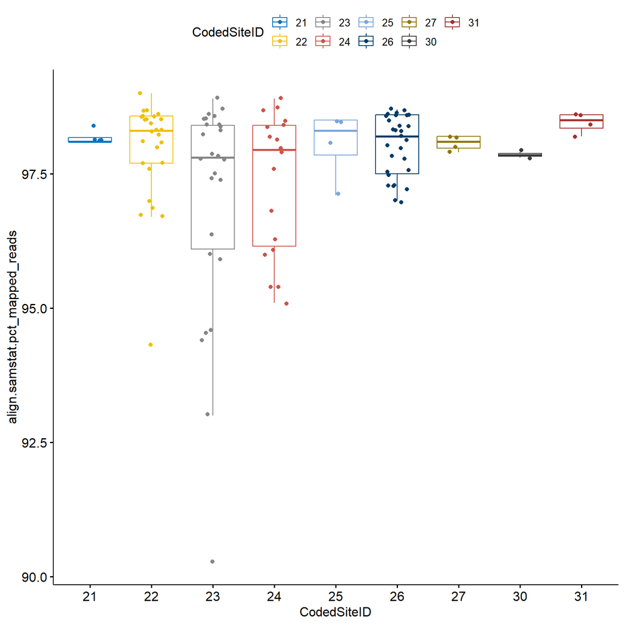

```r
ggboxplot(muscleatacmeta_expand,x = "CodedSiteID",y = "align.samstat.pct_mapped_reads",color = "CodedSiteID",palette = "jco",add = "jitter")
```

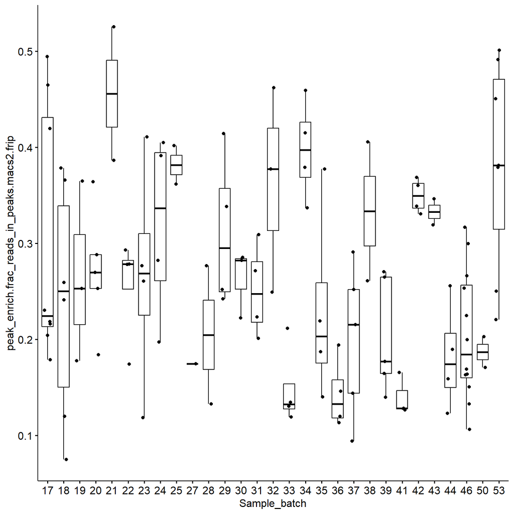

```r
ggboxplot(muscleatacmeta_expand,x = "Sample_batch",y = "peak_enrich.frac_reads_in_peaks.macs2.frip",palette = "jco",add = "jitter")
```

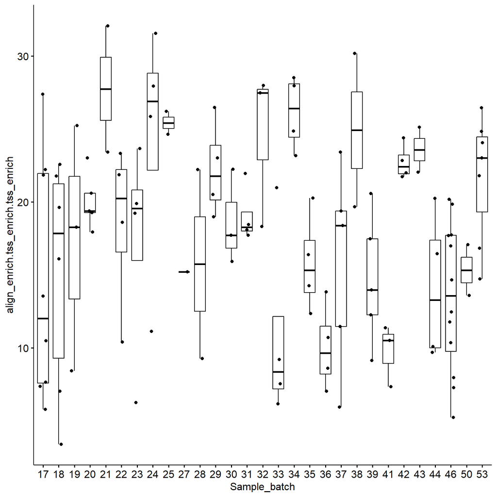

```r
ggboxplot(muscleatacmeta_expand,x = "Sample_batch",y = "align_enrich.tss_enrich.tss_enrich",palette = "jco",add = "jitter")
```

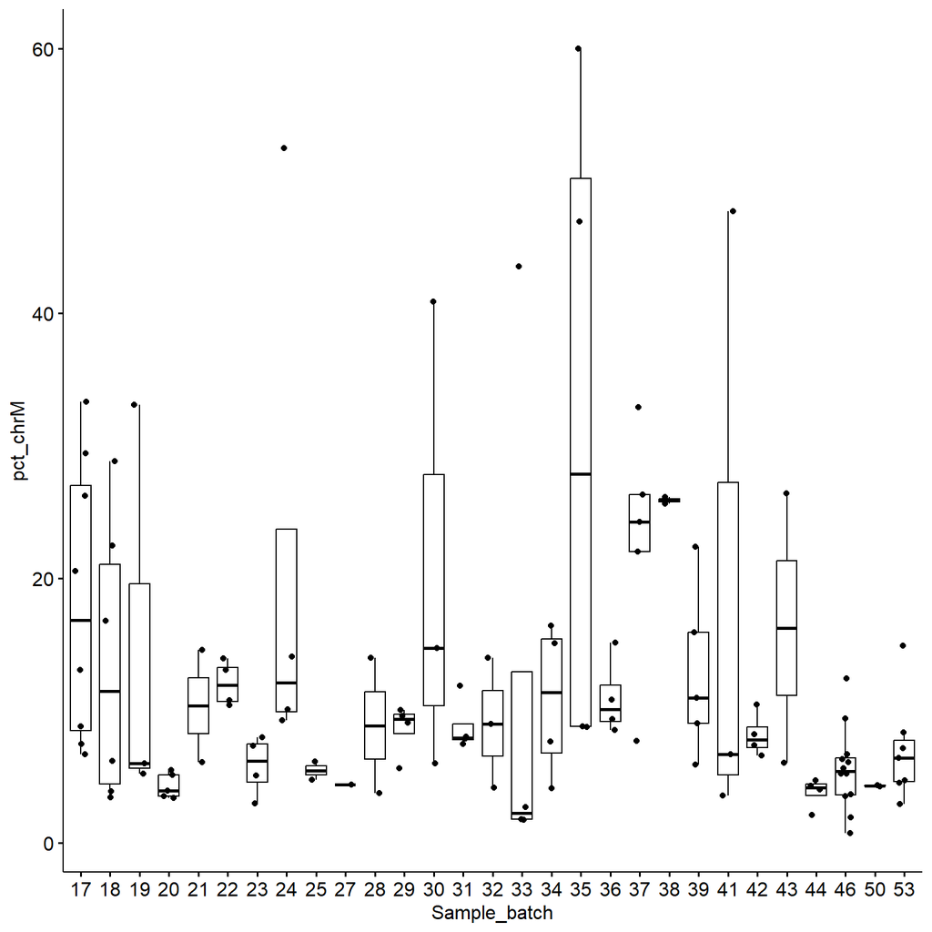

```r
ggboxplot(muscleatacmeta_expand,x = "Sample_batch",y = "pct_chrM",palette = "jco",add = "jitter")
```

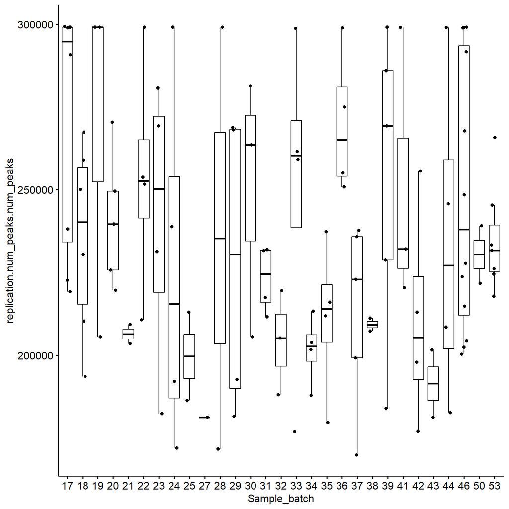

```r
ggboxplot(muscleatacmeta_expand,x = "Sample_batch",y = "replication.num_peaks.num_peaks",palette = "jco",add = "jitter")
```

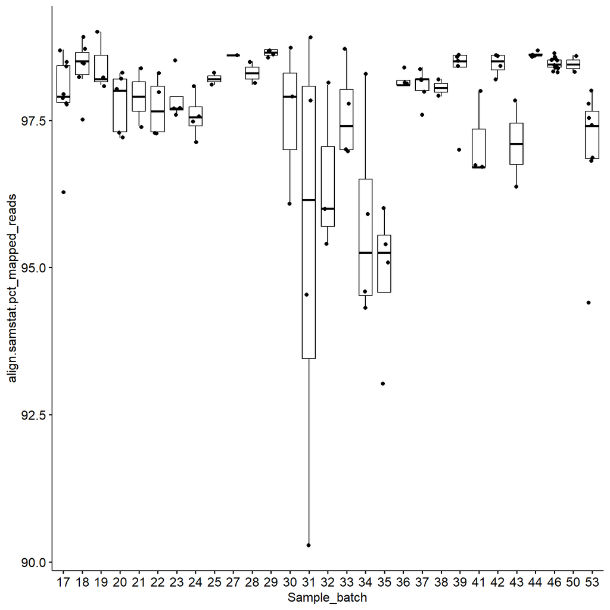

```r
ggboxplot(muscleatacmeta_expand,x = "Sample_batch",y = "align.samstat.pct_mapped_reads",palette = "jco",add = "jitter")
```

We filter out ATAC peaks with low counts and low sample representation and then normalize using calcNormFactors

```r
min_count = 10
min_samples = 6

muscleatac_filt_counts = muscleatac[rowSums(data.frame(lapply(muscleatac, function(x) as.numeric(x >= min_count)), check.names=FALSE)) >= min_samples,]

pre_dge <- DGEList(counts = muscleatac_filt_counts)
pre_dge <- calcNormFactors(pre_dge)

technical_covars_fixed = "Sample_batch + peak_enrich.frac_reads_in_peaks.macs2.frip + CodedSiteID"
biological_covars_fixed = "sex + age"
design_covars_fixed = "group_timepoint"

random_covars <- "(1 | pid)"
pre_only_form = paste0("~ 0 + ", design_covars_fixed, " + ", technical_covars_fixed, " + ", biological_covars_fixed, " + ", random_covars)
pre_only_meta = muscleatacmeta[muscleatacmeta$pre_or_post_visit == "ADU_BAS",]

pre_v <- voomWithDreamWeights(pre_dge, eval(parse(text = pre_only_form)), pre_only_meta)
```

```
## Memory usage to store result: >11.1 Gb
```

```
## Dividing work into 100 chunks...
```

```
##
## Total:19474 s
```

```r
muscleatac_norm <- pre_v$E
```

We conduct PCA analysis using prcomp and look at the correlation between PCs and QC metrics

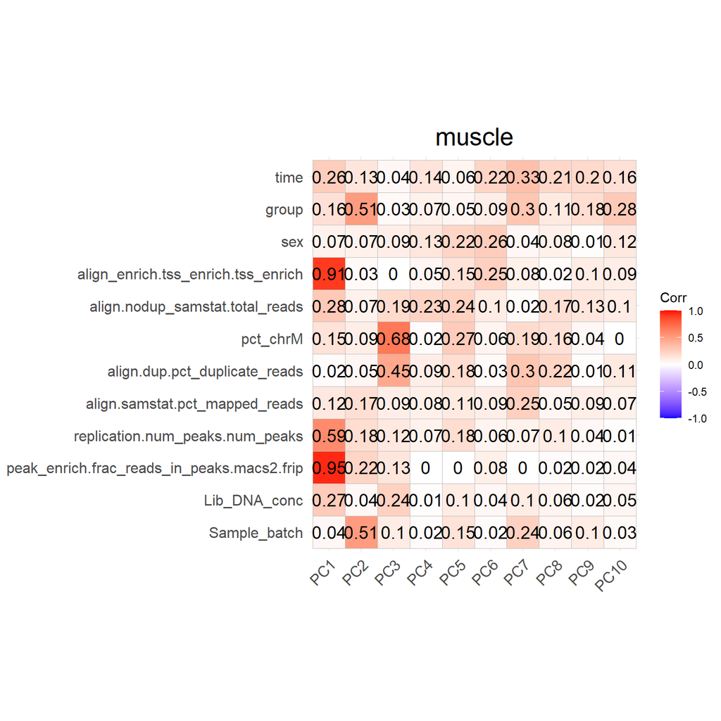

```r
qc_cols = c("Sample_batch", # batch of samples manually processed together
            "Lib_DNA_conc", # library concentration before pooling for sequencing
            "peak_enrich.frac_reads_in_peaks.macs2.frip",
            "replication.num_peaks.num_peaks",
            "align.samstat.pct_mapped_reads",
            "align.dup.pct_duplicate_reads",
            "pct_chrM",
            "align.nodup_samstat.total_reads", # more accurately number of reads after all filtering steps, i.e. used to call peaks
            "align_enrich.tss_enrich.tss_enrich",
            "sex",
            "group",
            "time")

muscleatac_select_meta <- muscleatacmeta_expand[,qc_cols]

muscle_pca_out = prcomp(t(muscleatac_norm), scale. = F, center = T)

muscleatac_select_meta = cbind(muscleatac_select_meta[colnames(muscleatac_norm),], muscle_pca_out$x[,1:10])

form = eval(parse(text=paste("~", paste(c(paste0("PC",1:10),qc_cols),collapse=" + "))))

muscleatac_C = canCorPairs(form, muscleatac_select_meta)

ggcorrplot(muscleatac_C[1:10,11:ncol(muscleatac_C)],lab=T,lab_size=5,hc.order = F) +
  ggtitle("muscle") +
  theme(plot.title = element_text(hjust = 0.5,size=20))
```

We do not find pca outliers, although we do find two FRIP outliers in adult sedentary samples. The identified FRIP cutoff is 0.1, and one outlier has a FRIP value of 0.094, while the other is at 0.075. Considering they are not PC outliers and we have limited samples, we do not exclude the FRIP outliers.

```
##     PC1     PC2     PC3     PC4     PC5     PC6     PC7     PC8     PC9    PC10
## 0.39045 0.08700 0.03455 0.02143 0.01759 0.01722 0.01573 0.01561 0.01417 0.01356
```

```
## The first 2 PCs were selected to identify outliers.
```

```
## No PC outliers.
```

```
## Plotting PCs. No outliers flagged.
```

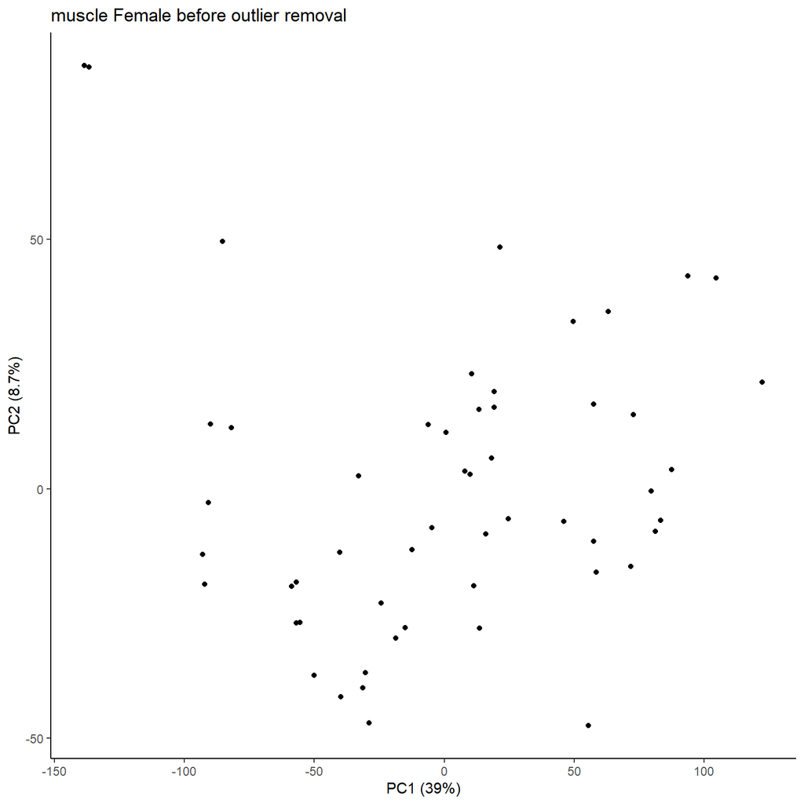

```r
muscleatacmeta_expandfem <- muscleatacmeta_expand[muscleatacmeta_expand$sex == "Female",]
muscleatacmeta_expandmal <- muscleatacmeta_expand[muscleatacmeta_expand$sex == "Male",]

muscleatac_norm_fem <- muscleatac_norm[,intersect(colnames(muscleatac_norm),rownames(muscleatacmeta_expandfem))]
muscleatac_norm_mal <- muscleatac_norm[,intersect(colnames(muscleatac_norm),rownames(muscleatacmeta_expandmal))]

muscle_fem_pca_out = MotrpacRatTraining6mo::call_pca_outliers(muscleatac_norm_fem, 0.075, plot=TRUE, verbose=TRUE, iqr_coef=3, title="muscle Female", M=10000)
```